# Financial Analytics

Séries Temporais: Fundamentos e Decomposição

Paloma Vaissman Uribe

Insper, PADS

Julio Trecenti

2026

## 🎯 Objetivos do Curso

Ao final do curso você será capaz de:

- **Analisar** dados temporais: tendências, sazonalidades e ruídos em séries financeiras
- **Selecionar** métodos estatísticos adequados ao problema de decisão
- **Ajustar e interpretar** modelos ARIMA e SARIMA
- **Programar** análises em Python

## 🗺️ Estrutura do Curso

### Forecasting

1. Fundamentos de séries temporais *(esta aula!)*
2. Modelagem SARIMA / Prophet

> 📝 **Trabalho intermediário**: 50% da nota

### Finance Applications

3. Fatos estilizados em finanças
4. Modelos de volatilidade
5. VaR, CAPM, Pair Trading, Carteira Ótima
6. Modelos multivariados
7. Apresentação de trabalhos

> 🎤 **Trabalho final**: 50% da nota

## 📌 Nesta Aula

**Parte 1: Fundamentos**

- Processo estocástico, i.i.d.
- Autocorrelação (ACF)
- Estacionariedade
- Random walk e ruído branco

**Parte 2: Componentes e Decomposição**

- Tabela de componentes
- Decomposição aditiva/multiplicativa
- Sazonalidade vista pela ACF (IBC-Br)
- Diferenciação sazonal e teste ADF

**Parte 3: PACF e Modelos**

- Autocorrelação Parcial (PACF)
- Identificação de modelos pela tabela ACF/PACF
- Processos AR, MA, ARMA
- Integração: ARIMA

**Nota**

**Aula 2:** SARIMA, Prophet e modelos de previsão com sazonalidade

# Parte 1 · Fundamentos

*Processo estocástico, autocorrelação e estacionariedade*

## 1 · Processo Estocástico & Série Temporal

Um **processo estocástico** é uma família de variáveis aleatórias indexadas pelo tempo:

$$X = \{X(t, \omega),\ t \in T,\ \omega \in \Omega\}$$

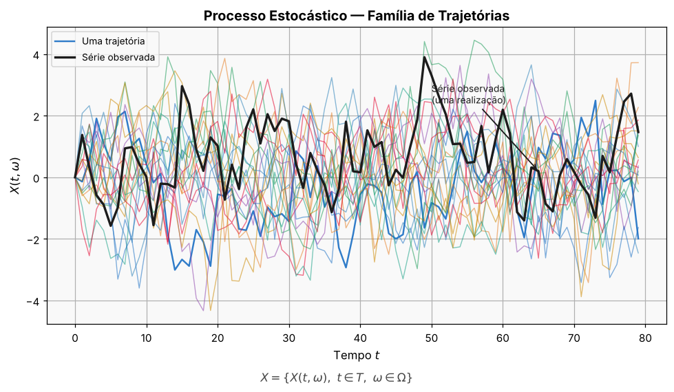

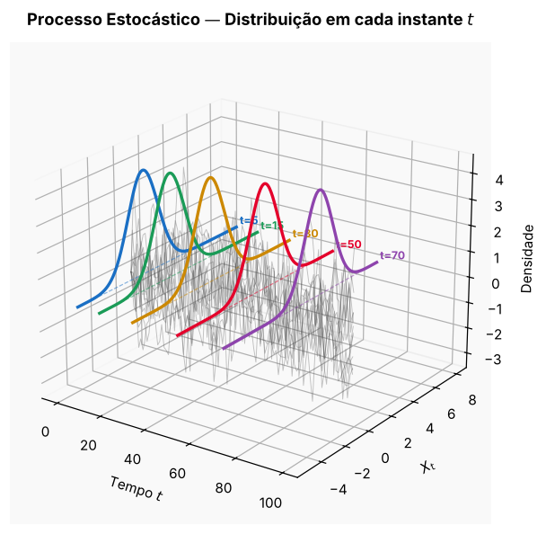

**Nota**

Cada **trajetória** $X^{(i)}(t)$ é uma **realização** do processo.  
A série temporal observada é **uma** dessas infinitas trajetórias possíveis.

## 2 · Breve revisão: Variável Aleatória

Uma **variável aleatória** é uma função que associa a cada elemento $\omega \in \Omega$ do espaço amostral um número real:

$$X: \Omega \to \mathbb{R}$$

**Nota**

**Exemplo:** ao jogar um dado não viciado, $\Omega = \{1,2,3,4,5,6\}$ e definimos $X$ como o resultado obtido, tal que $P(X = k) = \frac{1}{6}$ para $k = 1, \ldots, 6$.

Um **processo estocástico** é uma *sequência* de variáveis aleatórias: é exatamente o que ocorre ao jogar o dado 500 vezes e registrar os resultados consecutivos.

## 2 · O que é a ACF?

A **Função de Autocorrelação (ACF)** mede o grau de dependência linear entre $Y_t$ e seus valores passados $Y_{t-k}$:

$$\rho_k = \frac{\text{Cov}(Y_t,\, Y_{t-k})}{\text{Var}(Y_t)}$$

onde $k$ é chamado de **lag** (defasagem).

- $\rho_0 = 1$ sempre (correlação consigo mesmo)
- $\rho_k \in [-1, 1]$
- Se $|\rho_k| > \frac{1.96}{\sqrt{n}}$ → autocorrelação **significativa** no lag $k$
- ACF decaindo lentamente → série **não estacionária**
- ACF caindo rápido para zero → série **estacionária**

**Dica**

**Intuição:** a ACF responde *“o passado ajuda a prever o futuro?”* Se sim → há **memória** na série. Se não → processo é i.i.d.

## 2 · Processo i.i.d.

Quando as VAs são **independentes** e possuem a **mesma distribuição de probabilidade**, o processo é chamado **i.i.d.**:

```python
import numpy as np

n = 500

def dados(n, k):
    # Simula n lancamentos de um dado de k faces
    return np.random.randint(1, k + 1, size=n)

dados_gerados = dados(n, 6)
```

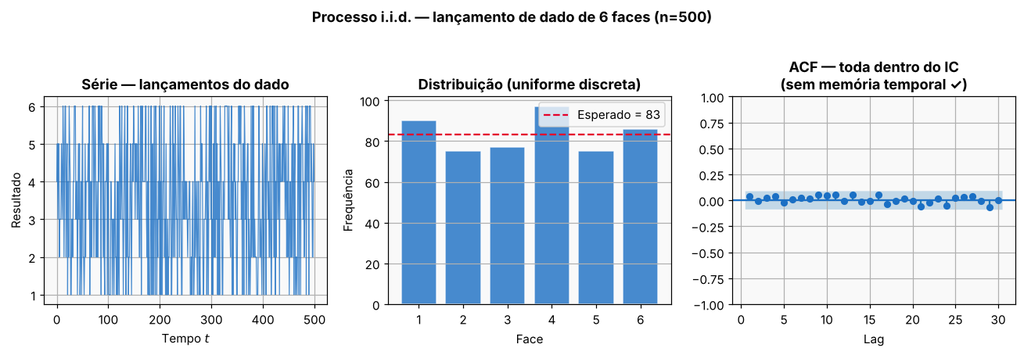

**Aviso**

Observe que a **ACF está toda dentro do intervalo de confiança**, confirmando ausência de dependência temporal. Séries temporais reais **não** são i.i.d.: há **memória** entre os pontos!

## 3 · Autocorrelação: Carregando os Dados

Usaremos o **IBC-Br** (BCB, código 24363), proxy mensal do PIB brasileiro:

```python
import pandas as pd
from python_bcb import sgs

# IBC-Br: Indice de Atividade Economica do Banco Central
ibc = sgs.get({'ibc': 24363}, start='2003-01-01')
ibc = ibc.dropna()
ibc.index = pd.to_datetime(ibc.index)
ibc.index.freq = 'MS'
```

**Nota**

O IBC-Br é calculado mensalmente pelo Banco Central e funciona como  
**proxy do PIB** antes da divulgação oficial pelo IBGE.  
Instale com: `pip install python-bcb`

## 3 · ACF do IBC-Br: Série em Nível

$$\rho_k = \text{Cor}(Y_t, Y_{t-k}) = \frac{\text{Cov}(Y_t, Y_{t-k})}{\text{Var}(Y_t)}$$

[figure not shown]

```python
import matplotlib.pyplot as plt
from statsmodels.graphics.tsaplots import plot_acf

fig, axes = plt.subplots(1, 2, figsize=(12, 4))
axes[0].plot(ibc.index, ibc['ibc'], color='#E4002B')
axes[0].set_title('IBC-Br: Índice Mensal (BCB 24363)')
plot_acf(ibc['ibc'], ax=axes[1], lags=24, title='ACF: Nível', zero=False)
plt.tight_layout(); plt.show()
```

**Dica**

## 4 · Estacionariedade

Um processo é **fracamente estacionário** quando possui:

| Propriedade | Condição |
| --- | --- |
| Média | Constante para todo $t$ |
| Variância | Constante para todo $t$ |
| Covariância | Função apenas da **defasagem** |

**Dica**

A ACF do IBC-Br decai muito lentamente: sinal claro de **não-estacionariedade** e presença de raiz unitária.

## 5 · Defasagem e Diferenciação

**Defasagem:** $y_{t-1},\ y_{t-2},\ \ldots$ | **Diferenciação:** $\Delta y_t = y_t - y_{t-1}$

```python
ibc['ibc_lag']  = ibc['ibc'].shift(periods=1)
ibc['ibc_diff'] = ibc['ibc'].diff(periods=1)
```

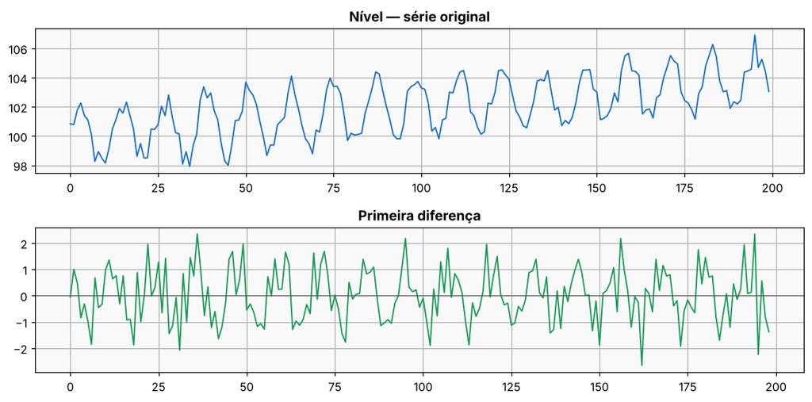

## 6 · Passeio Aleatório (*Random Walk*)

$$y_t = y_{t-1} + \varepsilon_t, \quad \varepsilon_t \sim RB(0, \sigma^2)$$

```python
np.random.seed(42)
n = len(ibc)
epsilon = np.random.normal(0, 1, n)
rw = np.zeros(n); rw[0] = epsilon[0]
for i in range(1, n): rw[i] = rw[i-1] + epsilon[i]
```

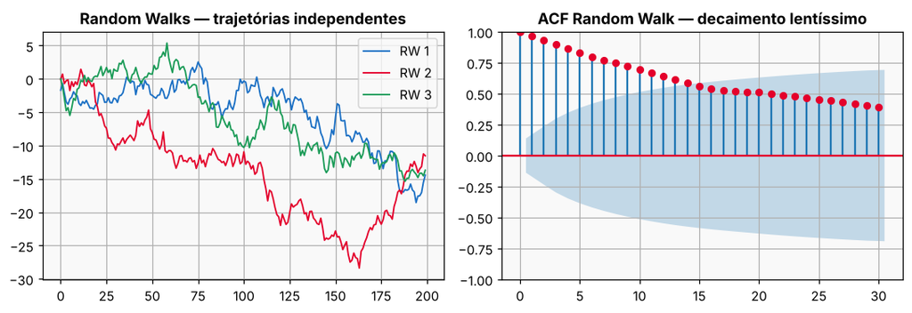

## 7 · Ruído Branco

Um **ruído branco** $\{\varepsilon_t\}$ é um processo estocástico com:

| Propriedade | Condição |
| --- | --- |
| Média | $E[\varepsilon_t] = 0$ |
| Variância | $\text{Var}(\varepsilon_t) = \sigma^2$ (constante) |
| Covariância | $\text{Cov}(\varepsilon_t, \varepsilon_s) = 0\ \forall\ t \neq s$ |

**Nota**

**Ruído branco gaussiano = processo i.i.d.** quando $\varepsilon_t \sim \mathcal{N}(0, \sigma^2)$

O ruído branco é o **componente residual ideal** de qualquer modelo de séries temporais: se os resíduos são ruído branco, o modelo capturou toda a estrutura da série.

**Na notação:**
$$\varepsilon_t \sim RB(0, \sigma^2)$$

- Sem memória → ACF $\approx 0$ para todo $k \neq 0$
- É estacionário por construção
- É o $\varepsilon_t$ do passeio aleatório: $y_t = y_{t-1} + \varepsilon_t$

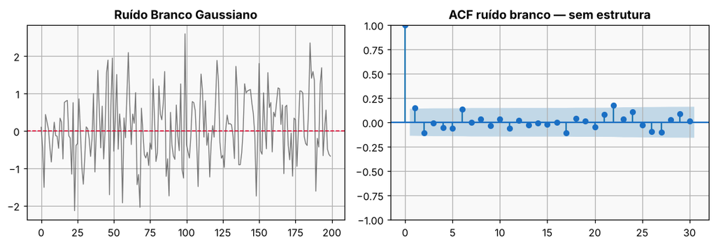